# (Explore Bike Share Data)

## by (Reham Rafee Ahmed)

## Investigation Overview

> In this investigation, I wanted to look at the factors that affect the duration of the trips and also the factors that cause increase or decrease in the number of the trips. The main focus was on the the gender of the members and their birth year the days of week the trips taken in and also the part of day.

## Dataset Overview

> The data consisted of trip duration and attributes of approximately 180000 member data. of info about trips taken by service's members, their types, their age, their gender, stations of starting and ending trips, duration of trips etc.I also developped new variables column from the provided start and end time of the trips those columns contain the day of the week which the trip done in also the part of day.

## ( Distribution of Trip Duration)

> Duration a lot of trips takes less than 1000 second. When plotted on a log-scale, the duration distribution looks unimodal, with one peak between 500 and 1000. In other words, most trips are short and do not exceed 15 minutes

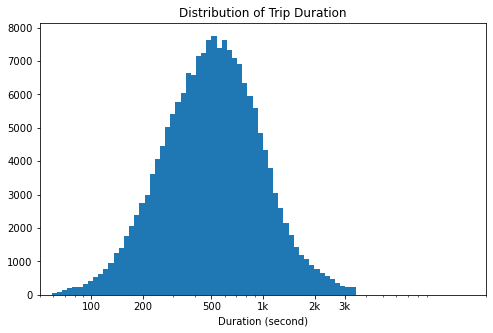

```python
log_binsize = 0.03
bins = 10 ** np.arange(0, np.log10(df_clean['duration_sec'].max())+log_binsize, log_binsize)

plt.figure(figsize=[8, 5])
plt.title('Distribution of Trip Duration')
plt.hist(data = df_clean, x = 'duration_sec', bins = bins)
plt.xlim([50, 2e4])
plt.xscale('log')
plt.xticks([ 100, 200, 500, 1000, 2e3, 3e3], [ 100, 200, 500, '1k', '2k', '3k'])
plt.xlabel('Duration (second)')
plt.show()
```

> Most users birth year falls between 1980 and 2000 In other words youth people

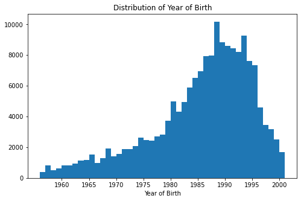

```python
binsize = 1
bins = np.arange(1956,df_clean['member_birth_year'].max()+binsize, binsize)

plt.figure(figsize=[8, 5])
plt.title('Distribution of Year of Birth')
plt.hist(data = df_clean, x = 'member_birth_year', bins = bins)
plt.xlabel('Year of Birth')
plt.xticks([ 1960, 1965, 1970, 1975, 1980, 1985, 1990, 1995,2000])
plt.show()
```

## (Distribution of member gender across the day of the week)

> First, We have a much more male users than females Second, The usage of the bike share system decrease in both Saturday and Sunday or the weekend

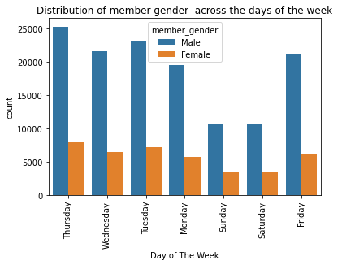

```python
sb.countplot(data = df_clean, x = 'trip_day_start', hue = 'member_gender')
plt.title('Distribution of member gender  across the days of the week')
plt.xlabel('Day of The Week')
plt.xticks(rotation=90);
```

## (Distribution of part of day trips across the day of the week)

> Through out the week most trips occur during the morning and noon period of the day with small difference except for the weekend where more trips occur during noon by big differnce than other periods.

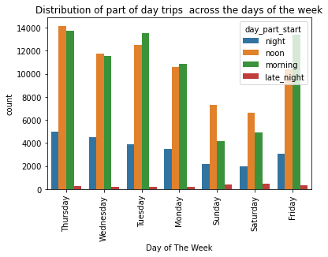

```python
sb.countplot(data = df_clean, x = 'trip_day_start', hue = 'day_part_start')
plt.title('Distribution of part of day trips  across the days of the week')
plt.xlabel('Day of The Week')
plt.xticks(rotation=90);
```

## (Distribution of Trip Duration across Member gender and the day of the week)

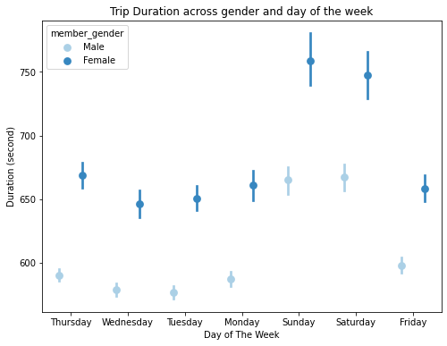

```python
fig = plt.figure(figsize = [8,6])
ax = sb.pointplot(data = df_clean, x = 'trip_day_start', y = 'duration_sec', hue = 'member_gender',
           palette = 'Blues', linestyles = '', dodge = 0.4)
plt.title('Trip Duration across gender and day of the week')
plt.ylabel('Duration (second)')
ax.set_yticklabels([],minor = True)
plt.xlabel('Day of The Week')
plt.show()
```